# sigident.preproc - Preprocessing GEO datasets

The R package `sigident.preproc` provides preprocessing functionalities and is part of the `sigident` package framework: https://gitlab.miracum.org/clearly/sigident

In order to apply the R package `sigident` and its functions on GEO datasets, these datasets have first to be downloaded and preprocessed. The preprocessing includes the creation of a merged gene expression data set, extraction of sample metadata and batch correction. The R package `sigident` can be found [here](https://gitlab.miracum.org/clearly/sigident).

# GEO platforms

Please note, that the GEO functionality of this R package has only been tested with the platforms, listed below:

- GPL570 [HG-U133_Plus_2] Affymetrix Human Genome U133 Plus 2.0 Array

# Setup

Initially, the R package needs to be loaded and the variable `datadir` and `plotdir` need to be defined. `datadir` points to the folder, where the GEO datasets are downloaded and stored. `plotdir` points to the folder, where the resulting plots created during the preprocessing are stored. `idtype` can be either “affy” or “entrez”, indicating, if either Affy-IDs or Entrez-IDs are to be used as feature names for the subsequent analyses. Selecting “entrez” usually results in a reduction of total features due to the removing of empty strings and duplicate IDs. We here use `idtype = "affy"` for all subsequent analyses.

```r
library(sigident.preproc)

# initialize filePath:
filePath <- tempdir()

# define datadir
maindir <- "./geodata/"
datadir <- paste0(maindir, "data/")
dir.create(maindir)
dir.create(datadir)

# define plotdir
plotdir <- "./plots/"
dir.create(plotdir)

# define idtype
idtype <- "affy"
```

# Definition of a list that contains a representation of the studie’s / studies’ metadata

This example uses the GEO lung cancer studies “GSE18842”, “GSE19804” and “GSE19188”, which contain in total 367 samples (197 tumor; 170 non-tumor) and 54,675 transcripts obtained by using Affymetrix GeneChip Human Genome U133 Plus 2.0 Array (platform GPL570).

The mapping information include the `setid` (which GEO set should be used, normally ‘1’), the `targetcolname` (the name of the column holding the variable of interest), the `targetlevelname` (the value of the positive outcomes in `targetcolname`) and the `controllevelname` (the value of the negative outcomes in `targetcolname`) need to be represented in the `studiesinfo` list object. If specifying `'use_rawdata' = TRUE`, raw the data is downloaded in CEL file format, uncompressed and subsequently normalized with a GCRMA normalization. The directory specified in `datadir` will be used for storing downloaded files.

```r
studiesinfo <- list(
  "GSE18842" = list(
    setid = 1,
    targetcolname = "source_name_ch1",
    targetlevelname = "Human Lung Tumor",
    controllevelname = "Human Lung Control"
    ),

  "GSE19804" = list(
    setid = 1,
    targetcolname = "source_name_ch1",
    targetlevelname = "frozen tissue of primary tumor",
    controllevelname = "frozen tissue of adjacent normal"
  ),

  "GSE19188" = list(
    setid = 1,
    targetcolname = "characteristics_ch1",
    controllevelname = "tissue type: healthy",
    targetlevelname = "tissue type: tumor",
    use_rawdata = TRUE
  )
)
```

In order to find these mapping information in the pheno data, one has probably to extract them manually from the studies, e.g. with the following commands for the study “GSE18842”:

```r
setid <- 1
datadir <- "./geodata/data/"
name <- "GSE18842"

# download eset
eset <- GEOquery::getGEO(name, destdir = datadir)[[setid]]

# View eset in Rstudio
View(Biobase::pData(eset))
```

Please be aware that currently, this package works only with binary classification, meaning, the target variable (specified in `targetcolname`) may only contain two levels. There are scenarios, where your target contains more than two levels. In such cases, this package supports two possible approaches:

- 1: You can specify only those two levels of interest with `controllevelname` and `targetlevelname`. During the loading process, the GEO sets will be reduced to only contain cases with these levels of interest.
- 2: You can specify more than one level for `controllevelname` and `targetlevelname`, repspectively. During the loading process, the levels specified in those variables will be summarized to one level, either “Control” or “Target”, in the merged data set. In order to achieve a such summarization of levels, please separate them by using three vertical lines (e.g. ‘|||’, unicode character ‘U+007C’). There MUST NOT be any addional character between the levels to be separated and the three vertical lines. The following code gives an example on how a splitting could look like for the GEO set ‘GSE58095’:

```r
studiesinfo <- list(
  "GSE58095" <- list(
    setid = 1,
    targetcolname = "characteristics_ch1.1",
    controllevelname = "group: Control|||group: SSc|||time point: Early|||time point: Late",
    targetlevelname = "tissue: skin biopsy"
  )
)
```

You can also specify all categories of one GEO set to belong to one group. For example, by setting `controllevelname` to NULL, all categories specified in `targetlevelname` are treated as targets and will internally be renamed accordingly.

```r
studiesinfo <- list(
  "GSE58095" <- list(
    setid = 1,
    targetcolname = "characteristics_ch1.1",
    controllevelname = NULL,
    targetlevelname = "tissue: skin biopsy|||group: Control|||group: SSc|||time point: Early"
  )
)
```

Caution: categories not specified in either `targetlevelname` or `controllevelname` will be excluded from the merging!

# Load GEO datasets

The function `load_geo_data` downloads the GEO datasets specified in the list `studiesinfo`. Further preprocessing steps are performed, such as the discovering, visualizing and removing of batch effectsa and the merging of the data.

Batch effects are systematic non-biological variation between studies due to experimental and technical artifacts. As first visualization a boxplot is created with the included samples on the x-axis and the expression values on the y-axis. Thereby, considerable discrepancies between the three studies used in this example can already be recognized.

A more powerfull and also here included approach for batch effect detection is conducting a guided Principle Component Analysis (gPCA) implemented in the gPCA package.

In order to correct for occurring batch effects and other unwanted variation in high-throughput experiments, the `ComBat` function from the sva package is also applied. The `ComBat` function adjusts for known batches using an empirical Bayesian framework [1].

`mergeset` results as output of the above described merging approach and represents a matrix containing batch corrected expression data with genes in the rows and samples in the columns, not an ExpressionSet anymore.

```r
load_geo_data(studiesinfo = studiesinfo,
              datadir = datadir,
              plotdir = plotdir,
              idtype = idtype)
```

## Visualize batch effect

These plots are created when executing the function `sigident.preproc::load_geo_data` and stored in the directory specified in `plotdir`.

### Before batch correction

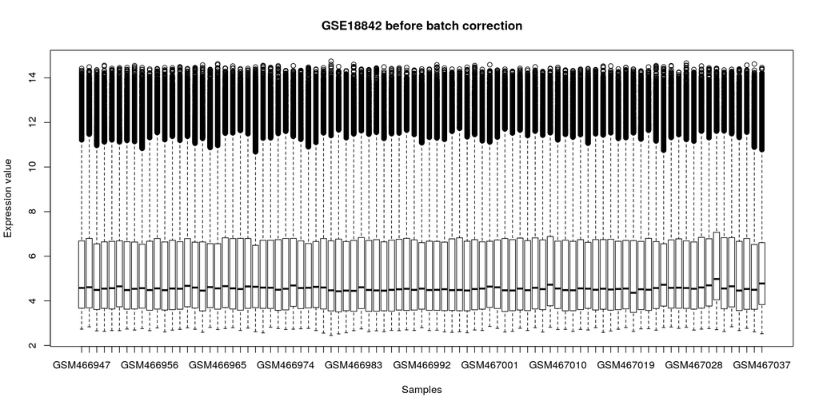

```r
knitr::include_graphics(paste0(plotdir, "GSE18842_batch_effect_boxplot.jpg"))
```

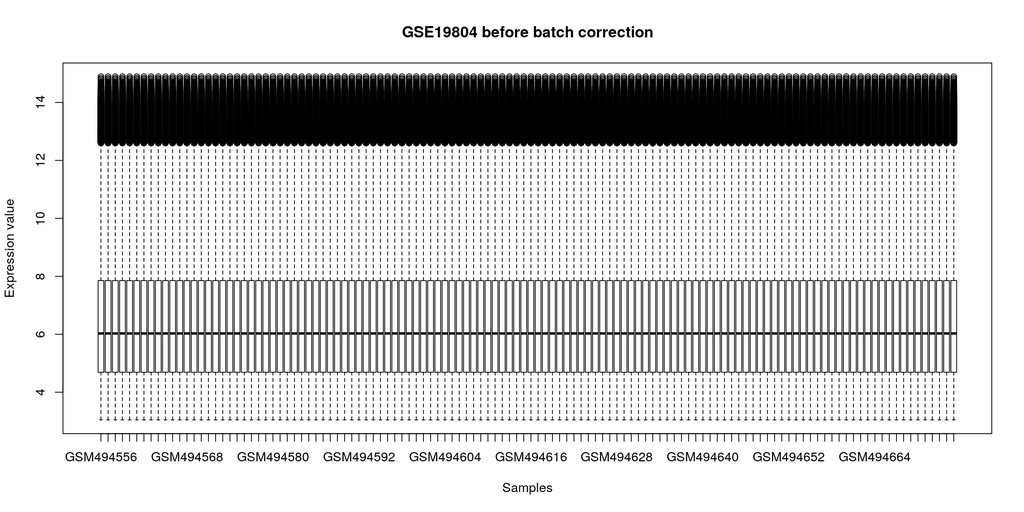

```r
knitr::include_graphics(paste0(plotdir, "GSE19804_batch_effect_boxplot.jpg"))
```

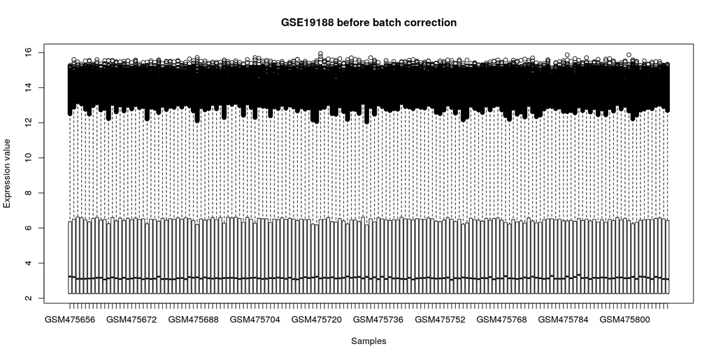

```r
knitr::include_graphics(paste0(plotdir, "GSE19188_batch_effect_boxplot.jpg"))
```

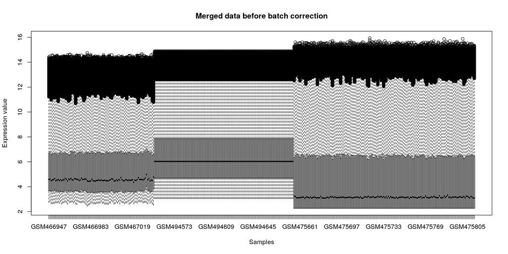

```r
knitr::include_graphics(paste0(plotdir, "Merged_before_batch_effect_boxplot.jpg"))
```

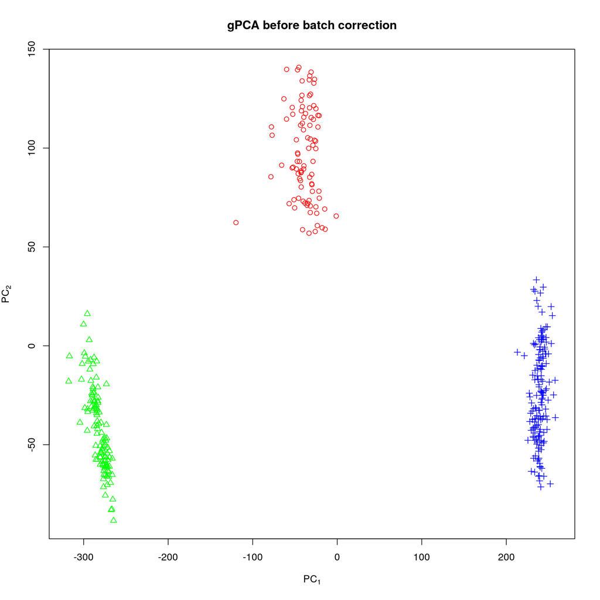

```r
knitr::include_graphics(paste0(plotdir, "PCplot_before.png"))
```

### After batch correction

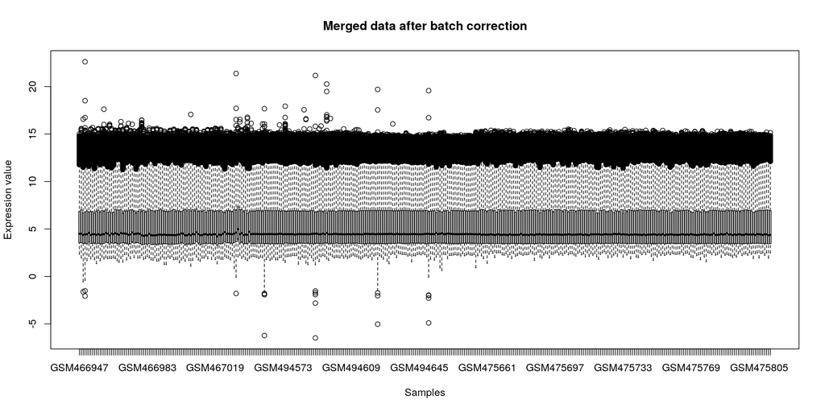

```r
knitr::include_graphics(paste0(plotdir, "Merged_after_batch_effect_boxplot.jpg"))
```

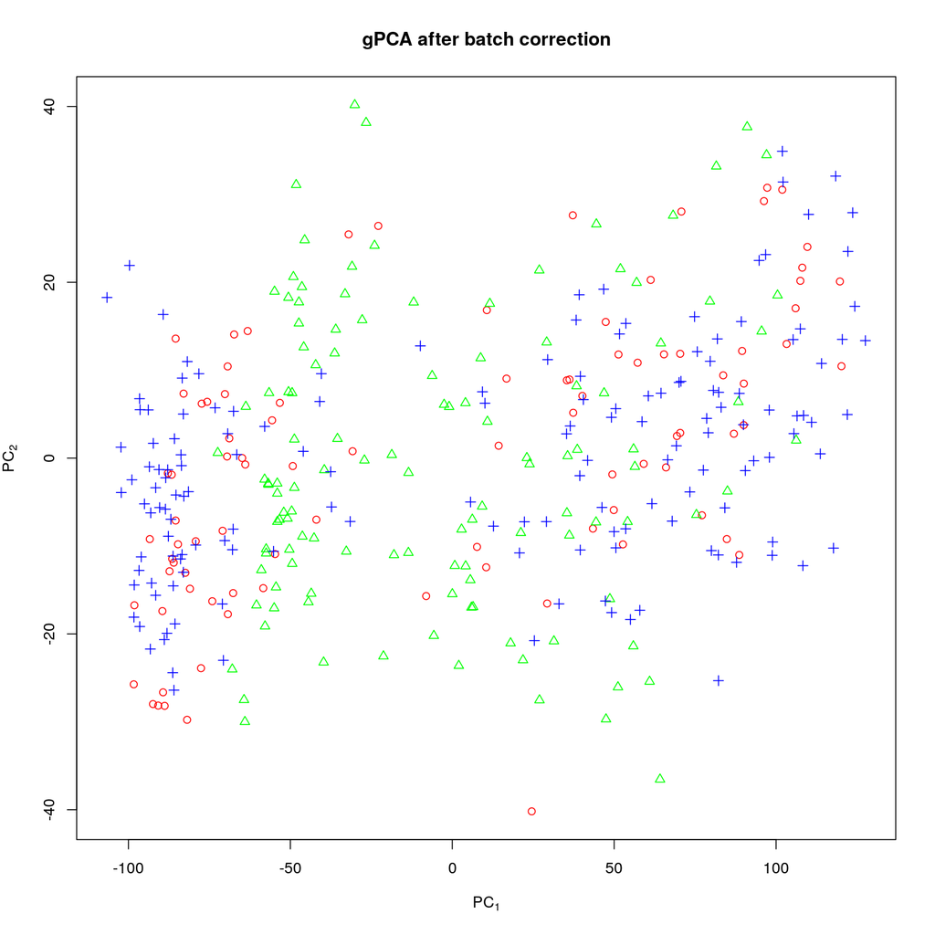

```r
knitr::include_graphics(paste0(plotdir, "PCplot_after.png"))
```

# List files in .Globalenv

All downloaded datasets and resulting objects, including `diagnosis`, `mergedset` and `mergeset` are assigned to the global environment and are suitable to be used in the subsequent analyses implemented in the R package `sigident`: https://gitlab.miracum.org/clearly/sigident.

```r
ls()
```

```
#>  [1] "affinity.spline.coefs" "batch"                 "datadir"
#>  [4] "diagnosis"             "filePath"              "GSE18842"
#>  [7] "GSE19188"              "GSE19804"              "idtype"
#> [10] "maindir"               "mergedset"             "mergeset"
#> [13] "plotdir"               "sample_metadata"       "studiesinfo"
```

# References

[1] W.E. Johnson, C. Li, and A. Rabinovic. Adjusting batch effects in microarray data using empirical bayes methods. Biostatistics, 8(1):118–127, 2007.